# Layout 3: polling locations and public libraries across Boston

Kristy Henrich

## Setup & load libraries

```r
library(sf)
library(tidyverse)
library(ggthemes)
library(ggspatial)
library(units)
library(nngeo)
library(RColorBrewer)
```

## Download spatial data

Data from data.boston.gov for:  
1. neighborhood boundaries (shape)  
2. voting precincts (shape)  
3. polling locations (point)  
4. public libraries (point)

```r
nhoods <- st_read("http://bostonopendata-boston.opendata.arcgis.com/datasets/3525b0ee6e6b427f9aab5d0a1d0a1a28_0.geojson?outSR={%22latestWkid%22:2249,%22wkid%22:102686}", quiet = TRUE)

precincts <- st_read("http://bostonopendata-boston.opendata.arcgis.com/datasets/2bc185ec9b0b478d8c2f7e720d116863_0.geojson?outSR={%22latestWkid%22:2249,%22wkid%22:102686}", quiet = TRUE)

polls <- st_read("http://bostonopendata-boston.opendata.arcgis.com/datasets/f7c6dc9eb6b14463a3dd87451beba13f_5.kml?outSR={%22latestWkid%22:2249,%22wkid%22:102686}", quiet = TRUE)

lib <- st_read("http://bostonopendata-boston.opendata.arcgis.com/datasets/cb00f9248aa6404ab741071ca3806c0e_6.geojson?outSR={%22latestWkid%22:2249,%22wkid%22:102686}", quiet = TRUE)
```

## Transform spatial data

Transform data to the Massachusetts State Plane system using projection from spatialreference.org

```r
MA_state_plane <- "+proj=lcc +lat_1=41.71666666666667 +lat_2=42.68333333333333 +lat_0=41 +lon_0=-71.5 +x_0=200000 +y_0=750000 +ellps=GRS80 +units=m +no_defs"

nhoods <- nhoods %>%
  st_transform(MA_state_plane)

precincts <- precincts %>%
  st_transform(MA_state_plane)

polls <- polls %>%
  st_transform(MA_state_plane)

lib <- lib %>%
  st_transform(MA_state_plane)
```

## Quick map & annotations

For this assignment, I used Carole’s tutorial and Taelor’s example assignment. Additionally, Alex helped me substantially with Figure 1

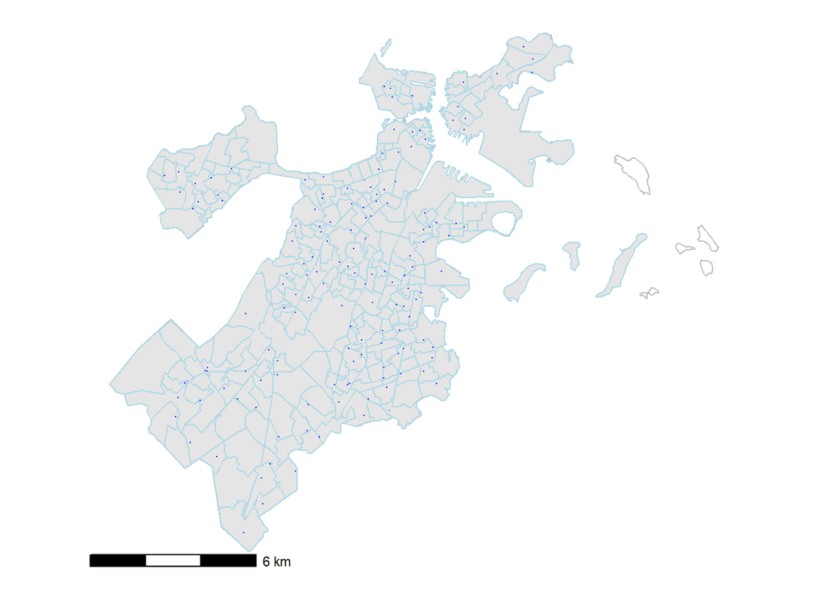

```r
ggplot(nhoods) +
  geom_sf(fill = NA, color = "gray") +
  geom_sf(data = precincts, color = "lightblue") +
  geom_sf(data = polls, color = "blue", size = 0.01) +
  geom_sf(data = lib, color = "pink", size = 0.01) +
  theme_map() +
  annotation_scale()
```

## Figure 1. Number & proportion of A points within a specified distance of B points

Number and proportion of unique polling locations within 400 meters of a public library

Create 400 m buffer around public libraries

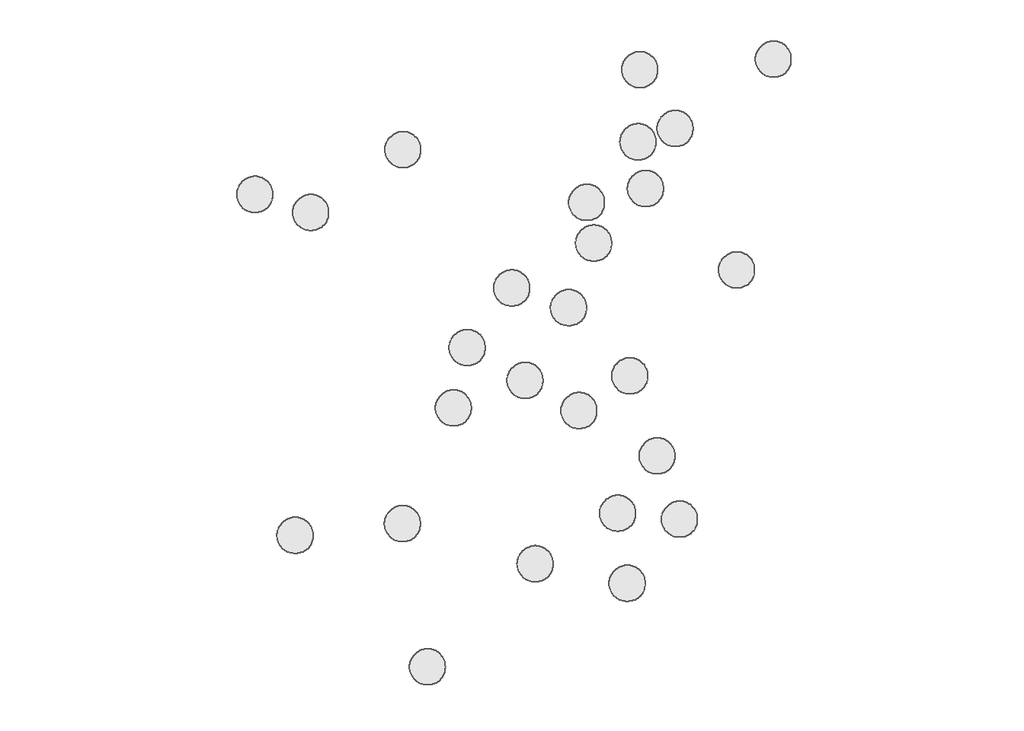

```r
lib_buffer <- st_buffer(lib, dist = 400) %>%
  st_union()
ggplot(lib_buffer) +
  geom_sf() +
  theme_map()
```

Plot polls within library buffer

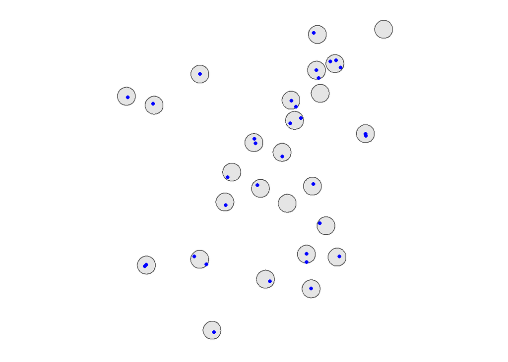

```r
polls_lib <- polls[lib_buffer,]

ggplot(lib_buffer) +
  geom_sf() +
  geom_sf(data = polls_lib,
          color = "blue",
          size = 1.5) +
  theme_map()
```

Calcuate how many unique polling locations are within 400 m of public library

```r
polls <- polls %>%
  st_join(polls_lib) %>%
  mutate(by_lib = !is.na(Name.y)) %>%
  st_intersection()

n_polls_by_lib <- sum(polls$by_lib)
n_polls_by_lib
```

```
## [1] 33
```

```r
n_polls <- length(polls$by_lib)

pct_polls_by_lib <- n_polls_by_lib / n_polls

pct_polls_by_lib
```

```
## [1] 0.2171053
```

About 22% of unique polling locations are within 400 m of a public library

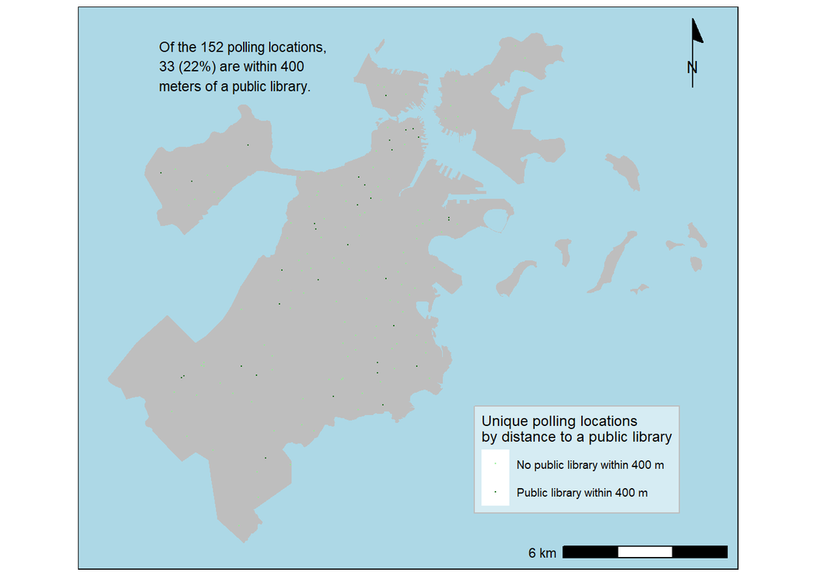

```r
left_side  <- st_bbox(lib)$xmin
top_side <- st_bbox(lib)$ymax

ggplot(nhoods) +
  geom_sf(fill = "gray", color = NA) +
  geom_sf(data = polls, size = 0.01,
          aes(color = by_lib)) +
  scale_color_manual(values = c("lightgreen", "darkgreen"),
          name = "Unique polling locations\nby distance to a public library",
          labels = c("No public library within 400 m",
                     "Public library within 400 m")) +
  annotation_scale(location = "br") +
  annotation_north_arrow(location = "tr",
                         style = north_arrow_minimal()) +
  annotate(geom = "text", x = left_side,
           y = top_side,
           label = paste("Of the ",
                         prettyNum(n_polls, big.mark = ","),
                         " polling locations,\n",
                         prettyNum(n_polls_by_lib, big.mark = ","),
                         " (",
                         prettyNum(100*pct_polls_by_lib, digits = 0),
                         "%) are within 400\nmeters of a public library.",
                         sep = ""),
           hjust = 0, vjust = 0, size = 3) +
  theme_map() +
  theme(panel.background = element_rect(fill = "lightblue"),
        legend.background = element_rect(fill = alpha("white", 0.5),
                                         color = "gray"),
        legend.position = c(.6, .1))
```

## Figure 2. Number and proportion of B points within C polygons

Calculate number and proportion of public libraries within neighborhoods

```r
nhoods <- nhoods %>%
  mutate(num_lib = lengths(st_covers(nhoods, lib)))
```

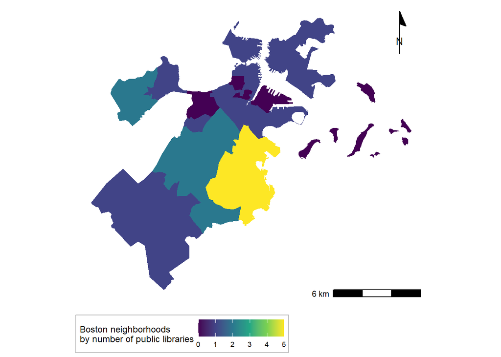

```r
lib_number <- ggplot(nhoods) +
  geom_sf(color = NA,
          aes(fill = num_lib)) +
  scale_fill_viridis_c(name = "Boston neighborhoods\nby number of public libraries") +
  annotation_scale(location = "br") +
  annotation_north_arrow(location = "tr",
                         style = north_arrow_minimal()) +

theme_map() +
  theme(legend.position = "bottom",
        legend.background = element_rect(fill = alpha("white", 0.5),
                                         color = "gray"))

lib_number
```

### Save Figure 2

```r
png(file="C:/Users/krist/OneDrive - Harvard University/GitHub/kristy_henrich-vis/libnumber.png",
width=600, height=350)
lib_number
dev.off()
```

## Figure 3. Number and proportion of C polygons containing A points

Number and proportion of neighborhoods containing polling locations

```r
nhoods <- nhoods %>%
  mutate(num_polls = lengths(st_covers(nhoods, polls)))
```

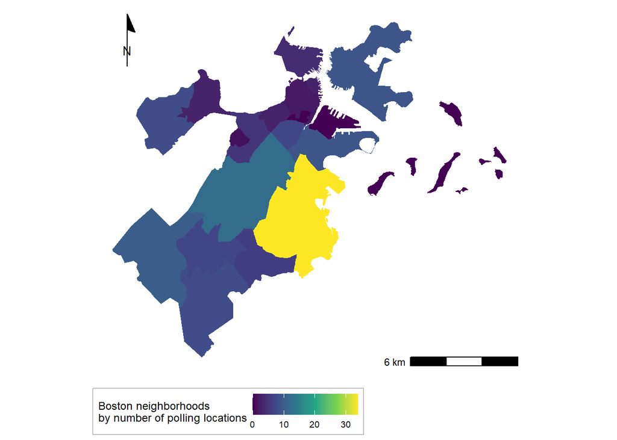

```r
poll_number <- ggplot(nhoods) +
  geom_sf(color = NA,
          aes(fill = num_polls)) +
  scale_fill_viridis_c(name = "Boston neighborhoods\nby number of polling locations") +
  annotation_scale(location = "br") +
  annotation_north_arrow(location = "tl",
                         style = north_arrow_minimal()) +

theme_map() +
  theme(legend.position = "bottom",
        legend.background = element_rect(fill = alpha("white", 0.5),
                                         color = "gray"))

poll_number
```

### Save Figure 3

```r
png(file="C:/Users/krist/OneDrive - Harvard University/GitHub/kristy_henrich-vis/pollnumber.png",
width=600, height=350)
poll_number
dev.off()
```

## Figure 4. Number and proportion of D polygons that overlap with C polygons

Number and proportion of voting precincts that overlap with neighborhoods

```r
nhoods <- nhoods %>%
  mutate(num_precincts = lengths(st_overlaps(nhoods, precincts))) %>%
  mutate(has_precinct = num_precincts > 0)
```

```r
n_prec_nhoods <- sum(nhoods$has_precinct)
n_prec_nhoods
```

```
## [1] 24
```

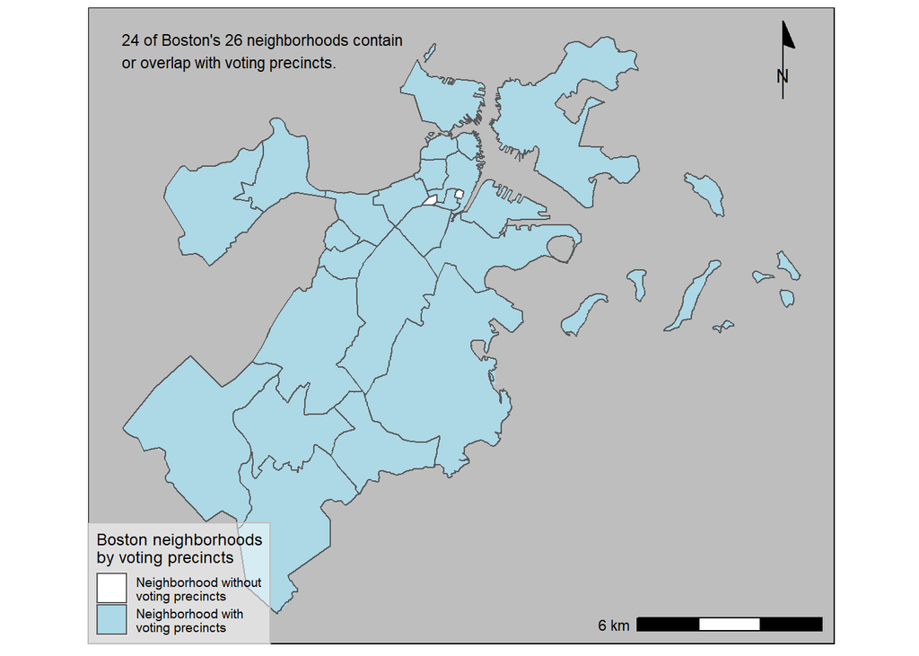

```r
left_side  <- st_bbox(precincts)$xmin
top_side <- st_bbox(precincts)$ymax

ggplot(precincts) +
  geom_sf(fill = "lightblue", color = NA) +
  geom_sf(data = nhoods,
          aes(fill = has_precinct)) +
  scale_fill_manual(values = c("white", "lightblue"),
          name = "Boston neighborhoods\nby voting precincts",
          labels = c("Neighborhood without\nvoting precincts",
                     "Neighborhood with \nvoting precincts")) +
  annotation_scale(location = "br") +
  annotation_north_arrow(location = "tr",
                         style = north_arrow_minimal()) +
  annotate(geom = "text", x = left_side,
           y = top_side - 1000,
           label = paste(n_prec_nhoods ,
                         "of Boston's",
                         length(nhoods$Name),
                         "neighborhoods contain\nor overlap with",
                         "voting precincts."),
           hjust = 0, vjust = 0, size = 3) +
  theme_map() +
  theme(panel.background = element_rect(fill = "gray"),
        legend.background = element_rect(fill = alpha("white", 0.5),
                                         color = "gray"))
```

## Figure 5. Average density of A points in each C polygon

Average density of public libraries in each neighborhood

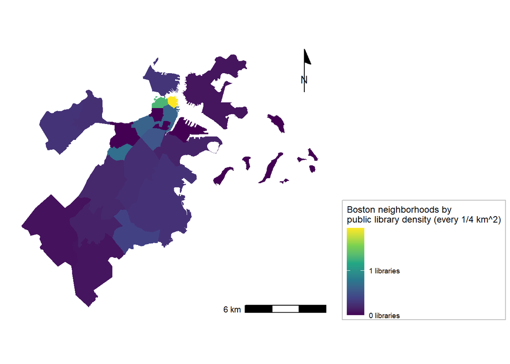

```r
nhoods <- nhoods %>%
  mutate(num_lib = lengths(st_covers(nhoods, lib)))%>%
  mutate(area = set_units(st_area(nhoods), km^2)) %>%
  mutate(lib_dens = as.numeric(num_lib / area))

lib_density <- ggplot(nhoods) +
  geom_sf(color = NA,
          aes(fill = lib_dens)) +
  scale_fill_viridis_c(name = "Boston neighborhoods by \npublic library density (every 1/4 km^2)",
                       breaks = breaks <- seq(0, 10, by = 1),
                       labels = paste(prettyNum(breaks, big.mark = ","),
                                      "libraries")) +
  annotation_scale(location = "br") +
  annotation_north_arrow(location = "tr",
                         style = north_arrow_minimal()) +
theme_map() +
  theme(legend.background = element_rect(fill = alpha("white", 0.5),
                                         color = "gray"),
        legend.position = "right")

lib_density
```

### Save Figure 5

```r
png(file="C:/Users/krist/OneDrive - Harvard University/GitHub/kristy_henrich-vis/libdensity.png",
width=600, height=350)
lib_density
dev.off()
```

## Figure 6. Average density of A points in each C polygon

Average density of polling locations in each neighborhood

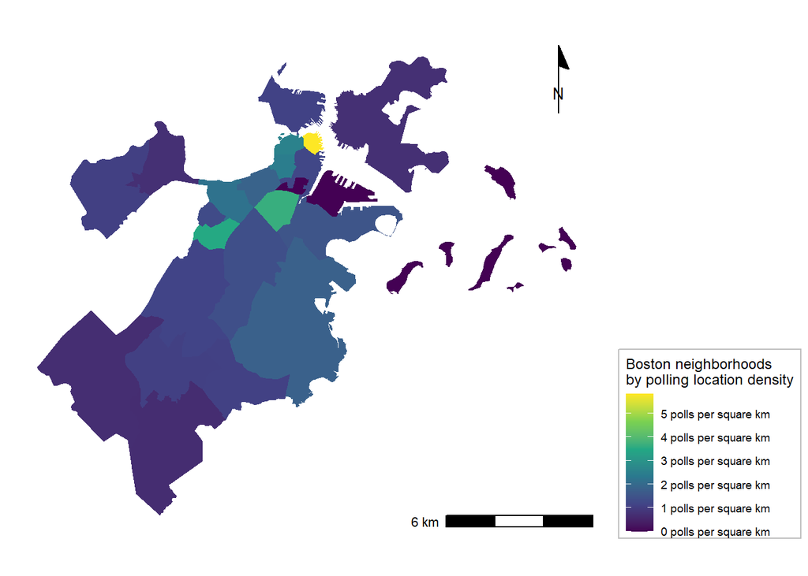

```r
nhoods <- nhoods %>%
  mutate(area = set_units(st_area(nhoods), km^2)) %>%
  mutate(poll_dens = as.numeric(num_polls / area))

poll_density <- ggplot(nhoods) +
  geom_sf(color = NA,
          aes(fill = poll_dens)) +
  scale_fill_viridis_c(name = "Boston neighborhoods\nby polling location density",
                       breaks = breaks <- seq(0, 10, by = 1),
                       labels = paste(prettyNum(breaks, big.mark = ","),
                                "polls per square km")) +
  annotation_scale(location = "br") +
  annotation_north_arrow(location = "tr",
                         style = north_arrow_minimal()) +
theme_map() +
  theme(legend.position = "right",
    legend.background = element_rect(fill = alpha("white", 0.5),
                                         color = "gray"))

poll_density
```

### Save Figure 6

```r
png(file="C:/Users/krist/OneDrive - Harvard University/GitHub/kristy_henrich-vis/polldensity.png",
width=600, height=350)
poll_density
dev.off()
```